# HW01

Jackson Dial

2022-09-07

# Shell Scripting

### Download from the Sakai HW1 folder the file named “heart-disease.csv.gz”. Upload this file to your DCC home directory.

```r
# sftp> put Data/heart-disease.csv.gz .
```

### Look at the first 5 lines and last 5 lines of the data file heart-disease.csv.gz without unzipping it. While this is not a very large dataset, we use it here to simulate working with a very large dataset that would be difficult or even impossible to open due to its size. Find out what “gzip” does by running the command “man gzip”. You may use “gzip” to complete this task.

```r
#zcat heart-disease.csv.gz | head -n 6

#zcat heart-disease.csv.gz | tail -n 5
```

### How many lines are there in this file? Find out without unzipping the file.

```r
#zcat heart-disease.csv.gz | wc -l

#There are 303 lines in the file
```

### Unzip heart-disease.csv.gz without deleting the original zipped file. You may use gunzip to accomplish this.

```r
# gunzip -c heart-disease.csv.gz > heart-disease.csv
```

### Find out how many patients are diagnosed with heart disease. To accomplish this, use the “grep” to find the lines that contain the word “TRUE” and count the lines. Since there is only one column containing TRUE/FALSE, hence we don’t need to worry about searching by column here, but if there were other columns in the same dataset that also contained true/false, you would need to search by column.

```r
# grep -c "TRUE" heart-disease.csv
# 139
```

### How many columns and how many rows are there in this dataset? Is the row count the same as the previous row count in question 3? If it is different, why do you think so? Show your commands that lead you to your answer.

```r
# awk '{print NF}' heart-disease.csv | sort -nu | tail -n 1
# there are 16 columns

# cat heart-disease.csv | wc -l
# there are 303 rows

# the row count is the same as above.
```

# Complete a Tutorial for “dplyr”

```r
# install.packages("tidyverse")
# install.packages("devtools")
```

```r
library(tidyverse)
# library(devtools)
# devtools::install_github("tidyverse/dplyr")
```

```r
starwars %>%
  filter(species == "Droid")
```

```
## # A tibble: 6 x 14
##   name   height  mass hair_color skin_color  eye_color birth_year sex   gender
##   <chr>   <int> <dbl> <chr>      <chr>       <chr>          <dbl> <chr> <chr>
## 1 C-3PO     167    75 <NA>       gold        yellow           112 none  masculi~
## 2 R2-D2      96    32 <NA>       white, blue red               33 none  masculi~
## 3 R5-D4      97    32 <NA>       white, red  red               NA none  masculi~
## 4 IG-88     200   140 none       metal       red               15 none  masculi~
## 5 R4-P17     96    NA none       silver, red red, blue         NA none  feminine
## 6 BB8        NA    NA none       none        black             NA none  masculi~
## # ... with 5 more variables: homeworld <chr>, species <chr>, films <list>,
## #   vehicles <list>, starships <list>
```

```r
starwars %>%
  select(name, ends_with("color"))
```

```
## # A tibble: 87 x 4
##    name               hair_color    skin_color  eye_color
##    <chr>              <chr>         <chr>       <chr>
##  1 Luke Skywalker     blond         fair        blue
##  2 C-3PO              <NA>          gold        yellow
##  3 R2-D2              <NA>          white, blue red
##  4 Darth Vader        none          white       yellow
##  5 Leia Organa        brown         light       brown
##  6 Owen Lars          brown, grey   light       blue
##  7 Beru Whitesun lars brown         light       blue
##  8 R5-D4              <NA>          white, red  red
##  9 Biggs Darklighter  black         light       brown
## 10 Obi-Wan Kenobi     auburn, white fair        blue-gray
## # ... with 77 more rows
```

```r
starwars %>%
  mutate(name, bmi = mass / ((height / 100)  ^ 2)) %>%
  select(name:mass, bmi)
```

```
## # A tibble: 87 x 4
##    name               height  mass   bmi
##    <chr>               <int> <dbl> <dbl>
##  1 Luke Skywalker        172    77  26.0
##  2 C-3PO                 167    75  26.9
##  3 R2-D2                  96    32  34.7
##  4 Darth Vader           202   136  33.3
##  5 Leia Organa           150    49  21.8
##  6 Owen Lars             178   120  37.9
##  7 Beru Whitesun lars    165    75  27.5
##  8 R5-D4                  97    32  34.0
##  9 Biggs Darklighter     183    84  25.1
## 10 Obi-Wan Kenobi        182    77  23.2
## # ... with 77 more rows
```

```r
starwars %>%
  arrange(desc(mass))
```

```
## # A tibble: 87 x 14
##    name    height  mass hair_color  skin_color eye_color birth_year sex   gender
##    <chr>    <int> <dbl> <chr>       <chr>      <chr>          <dbl> <chr> <chr>
##  1 Jabba ~    175  1358 <NA>        green-tan~ orange         600   herm~ mascu~
##  2 Grievo~    216   159 none        brown, wh~ green, y~       NA   male  mascu~
##  3 IG-88      200   140 none        metal      red             15   none  mascu~
##  4 Darth ~    202   136 none        white      yellow          41.9 male  mascu~
##  5 Tarfful    234   136 brown       brown      blue            NA   male  mascu~
##  6 Owen L~    178   120 brown, grey light      blue            52   male  mascu~
##  7 Bossk      190   113 none        green      red             53   male  mascu~
##  8 Chewba~    228   112 brown       unknown    blue           200   male  mascu~
##  9 Jek To~    180   110 brown       fair       blue            NA   male  mascu~
## 10 Dexter~    198   102 none        brown      yellow          NA   male  mascu~
## # ... with 77 more rows, and 5 more variables: homeworld <chr>, species <chr>,
## #   films <list>, vehicles <list>, starships <list>
```

```r
starwars %>%
  group_by(species) %>%
  summarise(
    n = n(),
    mass = mean(mass, na.rm = TRUE)
  ) %>%
  filter(
    n > 1,
    mass > 50
  )
```

```
## # A tibble: 8 x 3
##   species      n  mass
##   <chr>    <int> <dbl>
## 1 Droid        6  69.8
## 2 Gungan       3  74
## 3 Human       35  82.8
## 4 Kaminoan     2  88
## 5 Mirialan     2  53.1
## 6 Twi'lek      2  55
## 7 Wookiee      2 124
## 8 Zabrak       2  80
```

# Dataset Summary and Plotting

### Read the dataset into R by using a code chunk in your Rmd file.

```r
# setwd("C:/Users/jacks/OneDrive/Desktop/DUKE_FALL2022/707/BIOSTAT707")
dat <- read_csv("Data/heart_failure.csv")
```

### Use the summary function to show the summary statistics for the dataset. Print the summary. How many rows are there in this dataframe?

```r
library(pander)
summary(dat) %>%
  pander()
```

Table continues below

| age | anaemia | creatinine_phosphokinase | diabetes |
| --- | --- | --- | --- |
| Min. :40.00 | Min. :0.0000 | Min. : 23.0 | Min. :0.0000 |
| 1st Qu.:51.00 | 1st Qu.:0.0000 | 1st Qu.: 116.5 | 1st Qu.:0.0000 |
| Median :60.00 | Median :0.0000 | Median : 250.0 | Median :0.0000 |
| Mean :60.83 | Mean :0.4314 | Mean : 581.8 | Mean :0.4181 |
| 3rd Qu.:70.00 | 3rd Qu.:1.0000 | 3rd Qu.: 582.0 | 3rd Qu.:1.0000 |
| Max. :95.00 | Max. :1.0000 | Max. :7861.0 | Max. :1.0000 |

Table continues below

| ejection_fraction | high_blood_pressure | platelets | serum_creatinine |
| --- | --- | --- | --- |
| Min. :14.00 | Min. :0.0000 | Min. : 25100 | Min. :0.500 |
| 1st Qu.:30.00 | 1st Qu.:0.0000 | 1st Qu.:212500 | 1st Qu.:0.900 |
| Median :38.00 | Median :0.0000 | Median :262000 | Median :1.100 |
| Mean :38.08 | Mean :0.3512 | Mean :263358 | Mean :1.394 |
| 3rd Qu.:45.00 | 3rd Qu.:1.0000 | 3rd Qu.:303500 | 3rd Qu.:1.400 |
| Max. :80.00 | Max. :1.0000 | Max. :850000 | Max. :9.400 |

| serum_sodium | sex | smoking | time | DEATH_EVENT |
| --- | --- | --- | --- | --- |
| Min. :113.0 | Min. :0.0000 | Min. :0.0000 | Min. : 4.0 | Min. :0.0000 |
| 1st Qu.:134.0 | 1st Qu.:0.0000 | 1st Qu.:0.0000 | 1st Qu.: 73.0 | 1st Qu.:0.0000 |
| Median :137.0 | Median :1.0000 | Median :0.0000 | Median :115.0 | Median :0.0000 |
| Mean :136.6 | Mean :0.6488 | Mean :0.3211 | Mean :130.3 | Mean :0.3211 |
| 3rd Qu.:140.0 | 3rd Qu.:1.0000 | 3rd Qu.:1.0000 | 3rd Qu.:203.0 | 3rd Qu.:1.0000 |
| Max. :148.0 | Max. :1.0000 | Max. :1.0000 | Max. :285.0 | Max. :1.0000 |

```r
nrow(dat) #there are 299 rows in this df
```

```
## [1] 299
```

### How many people have anaemia? (Hint: Use functions in the dplyr package to help you get to this number)

```r
table(dat$anaemia)
```

```
##
##   0   1
## 170 129
```

```r
dat %>%
  filter(anaemia == 1) %>%
  nrow()
```

```
## [1] 129
```

```r
#129 people have anaemia
```

### How many death events occur in people who smoke?

```r
dat %>%
  filter(smoking == 1,
         DEATH_EVENT == 1) %>%
  nrow()
```

```
## [1] 30
```

```r
# There are 30 death events in people who smoke
```

### Plot a histogram of the number of deaths for each diabetes group using ggplot2. You may have to install the package using the function install.packages(“ggplot2”) and read through the ggplot tutorial to learn how to use ggplot2 commands. [Hint: remember that a death event is not continuous and should be designated as a Factor data type in R]

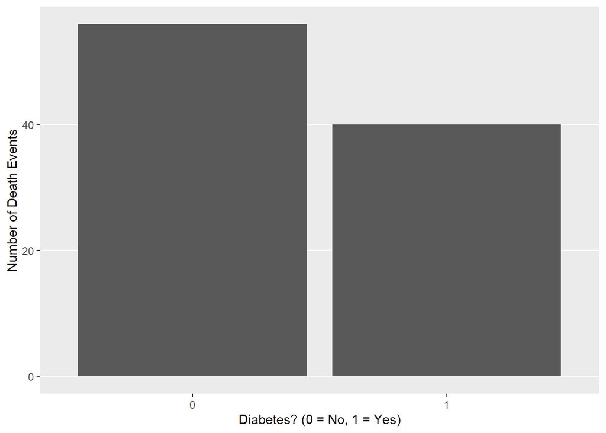

```r
ggplot(dat, aes(x = as.factor(diabetes), y = DEATH_EVENT))+
  geom_bar(stat = "identity")+
  theme(panel.grid.minor = element_blank(),
        panel.grid.major.x = element_blank())+
  labs(x = "Diabetes? (0 = No, 1 = Yes)",
       y = "Number of Death Events")
```